### Case Study 1

# 💰 Lending Club Analysis of Loans

```
(10000, 55)
```

Lending CLub allows individuals to lend money to other individuals. This data set includes the loans that were processed and not the loan applications. Hence, any loans that were not offered or not offer not accepted are not included.

A data frame with **10,000** observations on the following **55** variables.

### DATA DICTIONARY

| feature name | description |
| --- | --- |
| emp_title | Job title. |
| emp_length | Number of years in the job, rounded down. If longer than 10 years, then this is represented by the value 10. |
| state | Two-letter state code. |
| homeownership | The ownership status of the applicant's residence. |
| annual_income | Annual income. |
| verified_income | Type of verification of the applicant's income. |
| debt_to_income | Debt-to-income ratio. |
| annual_income_joint | If this is a joint application, then the annual income of the two parties applying. |
| verification_income_joint | Type of verification of the joint income. |
| debt_to_income_joint | Debt-to-income ratio for the two parties. |
| delinq_2y | Delinquencies on lines of credit in the last 2 years. |
| months_since_last_delinq | Months since the last delinquency. |
| earliest_credit_line | Year of the applicant's earliest line of credit |
| inquiries_last_12m | Inquiries into the applicant's credit during the last 12 months. |
| total_credit_lines | Total number of credit lines in this applicant's credit history. |
| open_credit_lines | Number of currently open lines of credit. |
| total_credit_limit | Total available credit, e.g. if only credit cards, then the total of all the credit limits. This excludes a mortgage. |
| total_credit_utilized | Total credit balance, excluding a mortgage. |
| num_collections_last_12m | Number of collections in the last 12 months. This excludes medical collections. |
| num_historical_failed_to_pay | The number of derogatory public records, which roughly means the number of times the applicant failed to pay. |
| months_since_90d_late | Months since the last time the applicant was 90 days late on a payment. |
| current_accounts_delinq | Number of accounts where the applicant is currently delinquent. |
| total_collection_amount_ever | The total amount that the applicant has had against them in collections. |
| current_installment_accounts | Number of installment accounts, which are (roughly) accounts with a fixed payment amount and period. A typical example might be a 36-month car loan. |
| accounts_opened_24m | Number of new lines of credit opened in the last 24 months. |
| months_since_last_credit_inquiry | Number of months since the last credit inquiry on this applicant. |
| num_satisfactory_accounts | Number of satisfactory accounts. |
| num_accounts_120d_past_due | Number of current accounts that are 120 days past due. |
| num_accounts_30d_past_due | Number of current accounts that are 30 days past due. |
| num_active_debit_accounts | Number of currently active bank cards. |
| total_debit_limit | Total of all bank card limits. |
| num_total_cc_accounts | Total number of credit card accounts in the applicant's history. |
| num_open_cc_accounts | Total number of currently open credit card accounts. |
| num_cc_carrying_balance | Number of credit cards that are carrying a balance. |
| num_mort_accounts | Number of mortgage accounts. |
| account_never_delinq_percent | Percent of all lines of credit where the applicant was never delinquent. |
| tax_liens | numeric vector |
| public_record_bankrupt | Number of bankruptcies listed in the public record for this applicant. |
| loan_purpose | The category for the purpose of the loan. |
| application_type | The type of application: either individual or joint. |
| loan_amount | The amount of the loan the applicant received. |
| term | The number of months of the loan the applicant received. |
| interest_rate | Interest rate of the loan the applicant received. |
| installment | Monthly payment for the loan the applicant received. |
| grade | Grade associated with the loan. |
| sub_grade | Detailed grade associated with the loan. |
| issue_month | Month the loan was issued. |
| loan_status | Status of the loan. |
| initial_listing_status | Initial listing status of the loan. (I think this has to do with whether the lender provided the entire loan or if the loan is across multiple lenders.) |
| disbursement_method | Dispersement method of the loan. |
| balance | Current balance on the loan. |
| paid_total | Total that has been paid on the loan by the applicant. |
| paid_principal | The difference between the original loan amount and the current balance on the loan. |
| paid_interest | The amount of interest paid so far by the applicant. |
| paid_late_fees | Late fees paid by the applicant. |

## Summary Statistics

|  | emp_title | emp_length | state | homeownership | annual_income | verified_income | debt_to_income | annual_income_joint | verification_income_joint | debt_to_income_joint | delinq_2y | months_since_last_delinq | earliest_credit_line | inquiries_last_12m | total_credit_lines | open_credit_lines | total_credit_limit | total_credit_utilized | num_collections_last_12m | num_historical_failed_to_pay | months_since_90d_late | current_accounts_delinq | total_collection_amount_ever | current_installment_accounts | accounts_opened_24m | months_since_last_credit_inquiry | num_satisfactory_accounts | num_accounts_120d_past_due | num_accounts_30d_past_due | … |
| --- | --- | --- | --- | --- | --- | --- | --- | --- | --- | --- | --- | --- | --- | --- | --- | --- | --- | --- | --- | --- | --- | --- | --- | --- | --- | --- | --- | --- | --- | --- |
| 0 | global config engineer | 3.0 | NJ | MORTGAGE | 90000.0 | Verified | 18.01 | NaN | NaN | NaN | 0 | 38.0 | 2001 | 6 | 28 | 10 | 70795 | 38767 | 0 | 0 | 38.0 | 0 | 1250 | 2 | 5 | 5.0 | 10 | 0.0 | 0 | … |
| 1 | warehouse office clerk | 10.0 | HI | RENT | 40000.0 | Not Verified | 5.04 | NaN | NaN | NaN | 0 | NaN | 1996 | 1 | 30 | 14 | 28800 | 4321 | 0 | 1 | NaN | 0 | 0 | 0 | 11 | 8.0 | 14 | 0.0 | 0 | … |
| 2 | assembly | 3.0 | WI | RENT | 40000.0 | Source Verified | 21.15 | NaN | NaN | NaN | 0 | 28.0 | 2006 | 4 | 31 | 10 | 24193 | 16000 | 0 | 0 | 28.0 | 0 | 432 | 1 | 13 | 7.0 | 10 | 0.0 | 0 | … |

|  | feature | count | mean | std | min | 25% | 50% | 75% | max |
| --- | --- | --- | --- | --- | --- | --- | --- | --- | --- |
| 0 | emp_length | 9183.0 | 5.930306 | 3.703734 | 0.00 | 2.0000 | 6.000 | 10.0000 | 1.000000e+01 |
| 1 | annual_income | 10000.0 | 79222.148412 | 64734.290492 | 0.00 | 45000.0000 | 65000.000 | 95000.0000 | 2.300000e+06 |
| 2 | debt_to_income | 9976.0 | 19.308192 | 15.004851 | 0.00 | 11.0575 | 17.570 | 25.0025 | 4.690900e+02 |
| 3 | annual_income_joint | 1495.0 | 127914.571244 | 70168.375404 | 19200.00 | 86833.5000 | 113000.000 | 151545.5000 | 1.100000e+06 |
| 4 | debt_to_income_joint | 1495.0 | 19.979304 | 8.054781 | 0.32 | 14.1600 | 19.720 | 25.5000 | 3.998000e+01 |
| 5 | delinq_2y | 10000.0 | 0.216000 | 0.683660 | 0.00 | 0.0000 | 0.000 | 0.0000 | 1.300000e+01 |
| 6 | months_since_last_delinq | 4342.0 | 36.760709 | 21.634939 | 1.00 | 19.0000 | 34.000 | 53.0000 | 1.180000e+02 |
| 7 | earliest_credit_line | 10000.0 | 2001.290000 | 7.795510 | 1963.00 | 1997.0000 | 2003.000 | 2006.0000 | 2.015000e+03 |
| 8 | inquiries_last_12m | 10000.0 | 1.958200 | 2.380130 | 0.00 | 0.0000 | 1.000 | 3.0000 | 2.900000e+01 |
| 9 | total_credit_lines | 10000.0 | 22.679600 | 11.885439 | 2.00 | 14.0000 | 21.000 | 29.0000 | 8.700000e+01 |
| 10 | open_credit_lines | 10000.0 | 11.404400 | 5.868280 | 0.00 | 7.0000 | 10.000 | 14.0000 | 5.100000e+01 |
| 11 | total_credit_limit | 10000.0 | 183606.230400 | 187632.707777 | 0.00 | 51593.7500 | 114667.000 | 267550.0000 | 3.386034e+06 |
| 12 | total_credit_utilized | 10000.0 | 51049.063100 | 53636.731172 | 0.00 | 19185.5000 | 36927.000 | 65421.0000 | 9.424560e+05 |
| 13 | num_collections_last_12m | 10000.0 | 0.013800 | 0.126535 | 0.00 | 0.0000 | 0.000 | 0.0000 | 3.000000e+00 |
| 14 | num_historical_failed_to_pay | 10000.0 | 0.167100 | 0.687768 | 0.00 | 0.0000 | 0.000 | 0.0000 | 5.200000e+01 |
| 15 | months_since_90d_late | 2285.0 | 46.112473 | 21.748021 | 2.00 | 29.0000 | 47.000 | 63.0000 | 1.280000e+02 |
| 16 | current_accounts_delinq | 10000.0 | 0.000100 | 0.010000 | 0.00 | 0.0000 | 0.000 | 0.0000 | 1.000000e+00 |
| 17 | total_collection_amount_ever | 10000.0 | 184.334000 | 2206.389859 | 0.00 | 0.0000 | 0.000 | 0.0000 | 1.993080e+05 |
| 18 | current_installment_accounts | 10000.0 | 2.663600 | 2.935387 | 0.00 | 1.0000 | 2.000 | 3.0000 | 3.500000e+01 |
| 19 | accounts_opened_24m | 10000.0 | 4.376100 | 3.158583 | 0.00 | 2.0000 | 4.000 | 6.0000 | 2.900000e+01 |
| 20 | months_since_last_credit_inquiry | 8729.0 | 7.340703 | 5.981590 | 0.00 | 2.0000 | 6.000 | 11.0000 | 2.400000e+01 |
| 21 | num_satisfactory_accounts | 10000.0 | 11.379600 | 5.859705 | 0.00 | 7.0000 | 10.000 | 14.0000 | 5.100000e+01 |
| 22 | num_accounts_120d_past_due | 9682.0 | 0.000000 | 0.000000 | 0.00 | 0.0000 | 0.000 | 0.0000 | 0.000000e+00 |
| 23 | num_accounts_30d_past_due | 10000.0 | 0.000100 | 0.010000 | 0.00 | 0.0000 | 0.000 | 0.0000 | 1.000000e+00 |
| 24 | num_active_debit_accounts | 10000.0 | 3.595300 | 2.434689 | 0.00 | 2.0000 | 3.000 | 5.0000 | 3.200000e+01 |
| 25 | total_debit_limit | 10000.0 | 27357.410300 | 26570.164081 | 0.00 | 10000.0000 | 19500.000 | 36100.0000 | 3.867000e+05 |
| 26 | num_total_cc_accounts | 10000.0 | 13.030000 | 7.874713 | 2.00 | 7.0000 | 11.000 | 17.0000 | 6.600000e+01 |
| 27 | num_open_cc_accounts | 10000.0 | 8.095000 | 4.906606 | 0.00 | 5.0000 | 7.000 | 10.0000 | 4.600000e+01 |
| 28 | num_cc_carrying_balance | 10000.0 | 5.230500 | 3.327623 | 0.00 | 3.0000 | 5.000 | 7.0000 | 4.300000e+01 |
| 29 | num_mort_accounts | 10000.0 | 1.383100 | 1.717274 | 0.00 | 0.0000 | 1.000 | 2.0000 | 1.400000e+01 |
| 30 | account_never_delinq_percent | 10000.0 | 94.648990 | 9.155059 | 14.30 | 92.6000 | 100.000 | 100.0000 | 1.000000e+02 |
| 31 | tax_liens | 10000.0 | 0.043300 | 0.593852 | 0.00 | 0.0000 | 0.000 | 0.0000 | 5.200000e+01 |
| 32 | public_record_bankrupt | 10000.0 | 0.123800 | 0.337172 | 0.00 | 0.0000 | 0.000 | 0.0000 | 3.000000e+00 |
| 33 | loan_amount | 10000.0 | 16361.922500 | 10301.956759 | 1000.00 | 8000.0000 | 14500.000 | 24000.0000 | 4.000000e+04 |
| 34 | term | 10000.0 | 43.272000 | 11.029877 | 36.00 | 36.0000 | 36.000 | 60.0000 | 6.000000e+01 |
| 35 | interest_rate | 10000.0 | 12.427524 | 5.001105 | 5.31 | 9.4300 | 11.980 | 15.0500 | 3.094000e+01 |
| 36 | installment | 10000.0 | 476.205323 | 294.851627 | 30.75 | 256.0400 | 398.420 | 644.6900 | 1.566590e+03 |
| 37 | balance | 10000.0 | 14458.916610 | 9964.561865 | 0.00 | 6679.0650 | 12379.495 | 20690.1825 | 4.000000e+04 |
| 38 | paid_total | 10000.0 | 2494.234773 | 3958.230365 | 0.00 | 928.7000 | 1563.300 | 2616.0050 | 4.163044e+04 |
| 39 | paid_principal | 10000.0 | 1894.448466 | 3884.407175 | 0.00 | 587.1000 | 984.990 | 1694.5550 | 4.000000e+04 |
| 40 | paid_interest | 10000.0 | 599.666781 | 517.328062 | 0.00 | 221.7575 | 446.140 | 825.4200 | 4.216440e+03 |
| 41 | paid_late_fees | 10000.0 | 0.119516 | 1.813468 | 0.00 | 0.0000 | 0.000 | 0.0000 | 5.298000e+01 |

```
array(['MORTGAGE', 'RENT', 'OWN'], dtype=object)
```

```
Source Verified    4116
Not Verified       3594
Verified           2290
Name: verified_income, dtype: int64
```

```
(8505, 55)
(1495, 55)
```

```
individual    8505
joint         1495
Name: application_type, dtype: int64
```

### Missing Value Analysis

We will be checking for any null values in the data set has most ML don't work well with missing values. After our analysis we will decide what we should do with the missing values (whether to drop them or fill them and filling strategy in case of latter)

```
verification_income_joint           8545
annual_income_joint                 8505
debt_to_income_joint                8505
months_since_90d_late               7715
months_since_last_delinq            5658
months_since_last_credit_inquiry    1271
emp_title                            833
emp_length                           817
num_accounts_120d_past_due           318
debt_to_income                        24
dtype: int64
```

```
Individual Applicants
annual_income_joint                 8505
verification_income_joint           8505
debt_to_income_joint                8505
months_since_90d_late               6492
months_since_last_delinq            4770
months_since_last_credit_inquiry    1052
emp_title                            630
emp_length                           615
num_accounts_120d_past_due           318
sub_grade                              0
dtype: int64
```

```
Joint Applicants
months_since_90d_late               1223
months_since_last_delinq             888
months_since_last_credit_inquiry     219
emp_title                            203
emp_length                           202
verification_income_joint             40
dtype: int64
```

```
[nan 'Verified' 'Not Verified' 'Source Verified']
['Verified' 'Not Verified' 'Source Verified']
```

P: Looking at the null values we can there are 40 rows in verification of income for joint applicant that shouldn't be null since there are 8505 individuals applicants only. This means there is missing information for 40 joint applicant on their income verification status.

**We can solve this by making these 40 missing values equal to 'Not Verified'.**

Therefore the first three features from above are correct since we have 8505 individual applicants.

--

**Title is a redundant feature from analysis point of view as there are ~4000 unique titles, for employee length, I have chosen to use mean of the feature to fill missing values.**

--

**As the number of values are so low, I have chosen to remove them from the data set.**

--

For remaining issues I will be performing further analysis

## Visualizing Data

### Top Professions lending on the platform

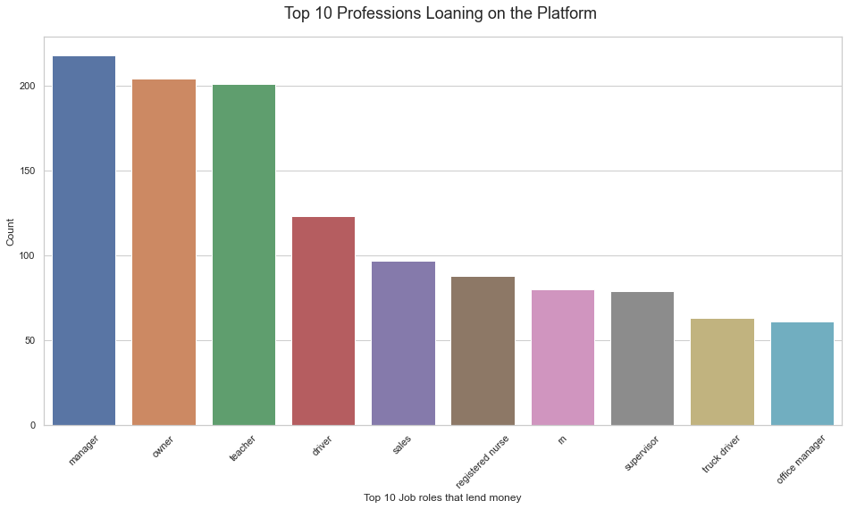

From the above plot it is evident what the applicants on the platform do for living. A huge chunk of loans are taken by managers and business owners but surprisingly even teachers make a huge chunk of the data set. As of writing this notebook, the job title "rn" is currently unknown but it is a part of the top 10.

### Grade and Interest Rate

> **ASSUMPTION**: The grades are assigned as per interest rate and they are used to divide the interest rate into classes

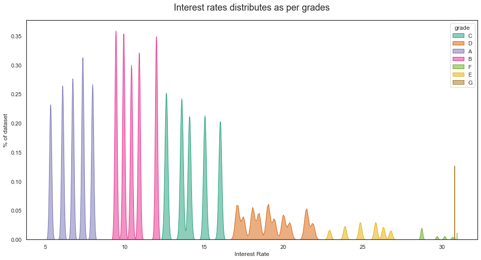

As we can see our assumptions of grade and interest rate relationship hold. From the above graph we can see the number of applicants drop after 15% interest rate. And then there is huge spike with Grade G applicants. These are very risky loan applicants having a very high interest rate. As the applicants become risker they drop from taking the loan and its seen with the numbers.

### Loan Amounts in Grades

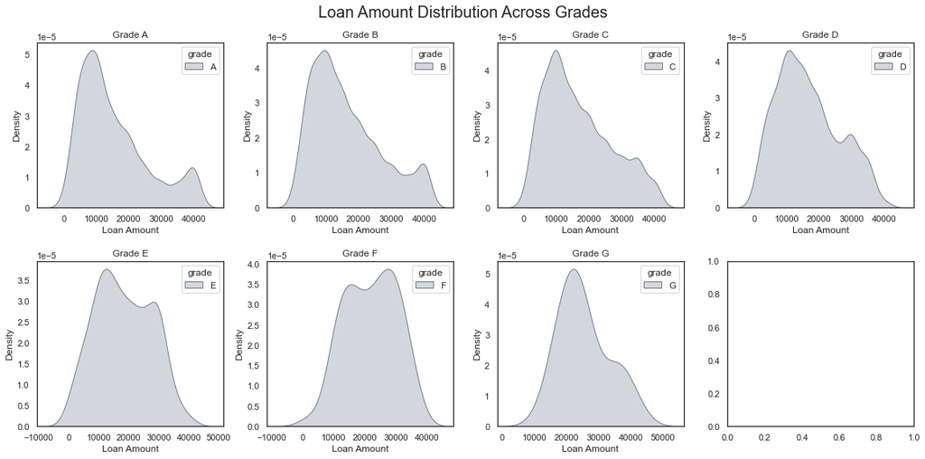

It is important to understand if the loan amount has effect on the grade and in turn the loan amount. On plotting the loan amount distribution for each grade it is very evident the peak of the distribution shifts towards the right as the grade increases. Loans with higher interest rate are often against a higher loan amount. The shift in the peak can be seen gradually happen from grade A-E.

### Top Purpose for getting a loan

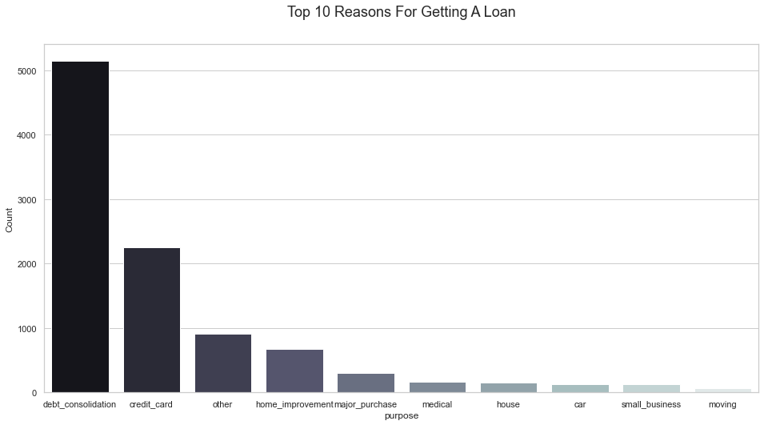

It can be seen that people on the platform about half of them are getting loans for the purpose of paying out other loans. The half of the remaining are using the loans to pay off their credit cards. This makes sense as Lending Club is a platform unlike a financial institution which would term debt consolidation a risky purpose to lend money.

### Loan Lenders distribution by state

> Could not be implenented to plot on a map in time.

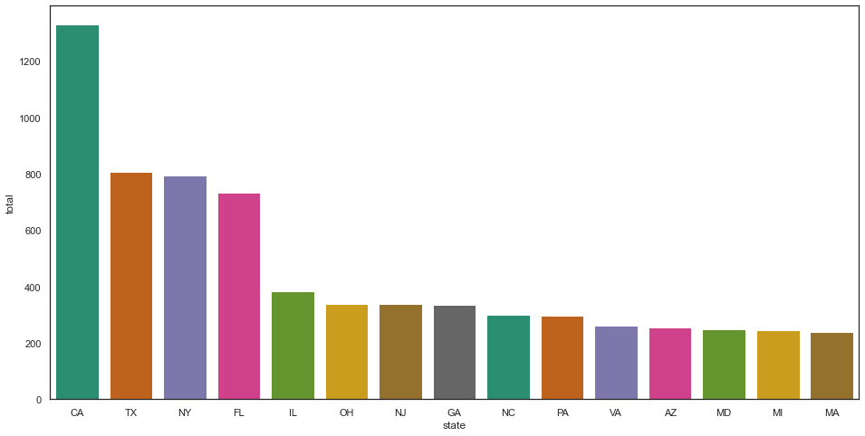

The above is representation of where most of Lending Club's loan applicants come from. As we can see they are predominately from affluent states like California, Texas, New York. These states have an abundance of wealth coming from tech companies and financial services and as we saw before it was managers and business owners at the top of profession list who apply for loans.